# Homework 4

This asg. asks:

> Fit a model to real data, or find a table of model results, and [plot?] one or two plots illustrating a statistical inference. Let us know if you need help finding a data set, or a plausible scientific question to attack with a model.

This asg fits an SIRD model to the Eyam plague using NUTS in Turing.jl. Code for the actual model can be found in the EyamSIRD.jl file attached.

The model is

$$\begin{aligned}
&\frac{d S}{d t}=-\frac{\beta I S}{N} \\
&\frac{d I}{d t}=\frac{\beta I S}{N}-\gamma I-\mu I \\
&\frac{d R}{d t}=\gamma I \\
&\frac{d D}{d t}=\mu I
\end{aligned}$$

The initial data from the plague is as follows: we have a time series of deaths recorded by the church in Eyam around the time of the great plague:

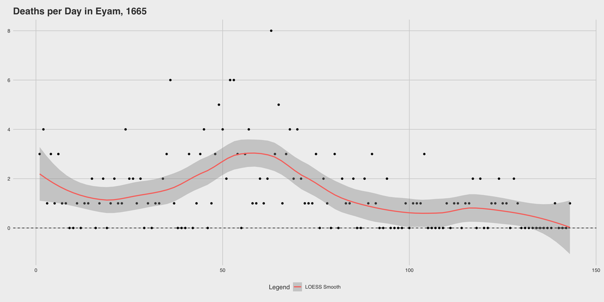

We have priors:

$$\begin{aligned}
&\sigma \sim \text { Inv-Gamma }(3,1)\\
&\beta \sim \mathcal{N}(0.9, 4)\\
&\gamma \sim \mathcal{N}(0.4, 4)\\
&\mu \sim \mathcal{N}(0.4, 4)
\end{aligned}$$

with every normal distribution truncated at zero and ten, and $\sigma$ as the expected noise in our data.

We want to make the following inferences — first, we want to recover and view the posterior densities associated with our SIRD parameters. Second, we want to estimate the values for our other compartments, as we fit the model only to deaths.

To start, we read in our model output from Julia, and plot the posterior distribution of the $\mu$ (mortality) and $\beta$ (rate of infection) parameters.

The shaded area represents the 80% CI, with the point estimate at the posterior mean.

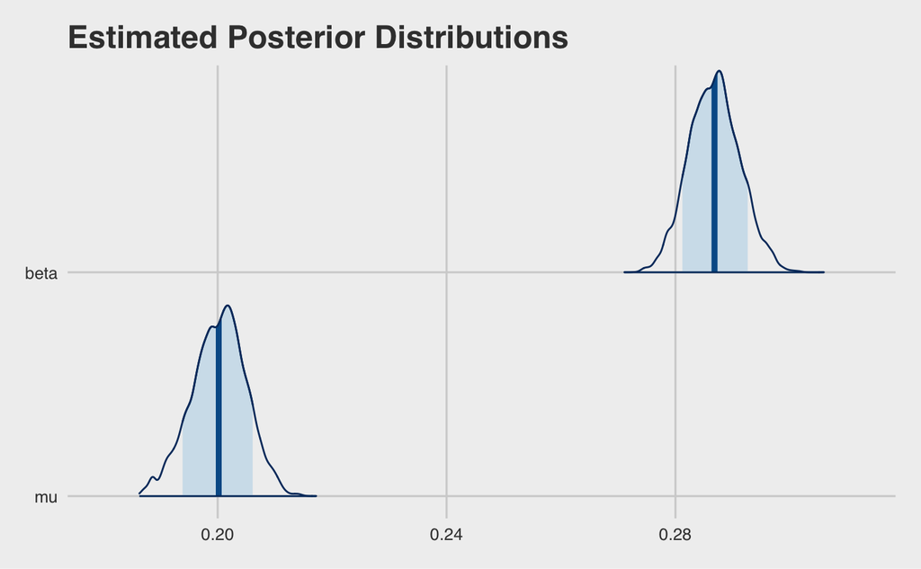

Above we only plotted two parameters, because the scope of the other parameters makes the graph illegible if they are plotted together.

We can plot every posterior distribution seperately also:

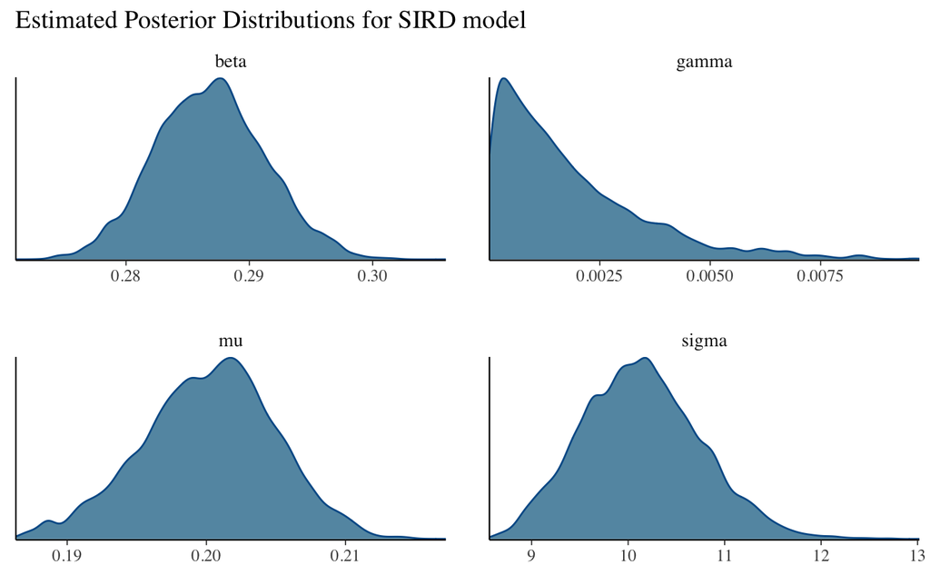

Now for the visualization of the different compartments:

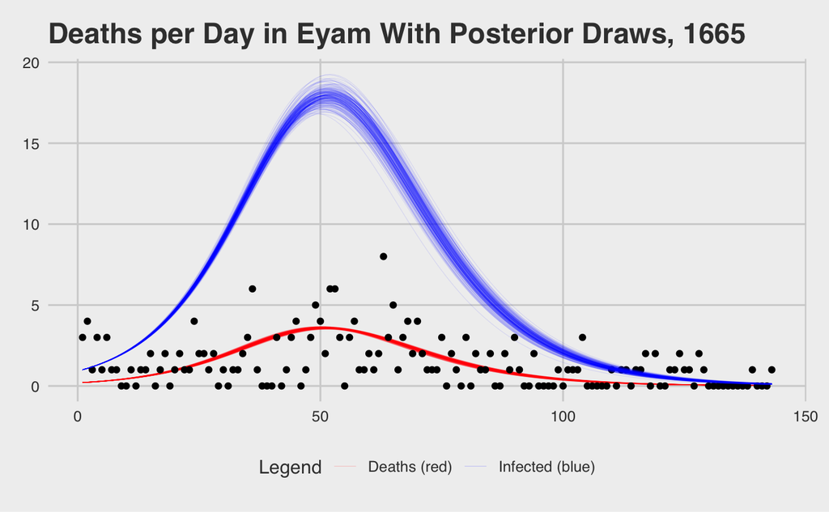

Notice how the infered infection category for which we lack any data has a larger range of uncertainty in the distribution of possible fits compared to the deaths time series for which we have data.

On a related note, even though this model is clearly a bad choice for this plague, and way too simple, the estimated death trajectories provide what seems like an intuitively more reasonable fit than the LOESS smooth.